# Data Science 2: Advanced Topics in Data Science

#### **Build & Compile Model**

```python
def transformer_encoder(inputs, embed_dim, num_heads, ff_dim, rate=0.2):
    # Multi-head attention
    attention_output = layers.MultiHeadAttention(num_heads=num_heads, key_dim=embed_dim)(inputs, inputs)
    attention_output = layers.Dropout(rate)(attention_output)
    attention_output = layers.LayerNormalization(epsilon=1e-6)(inputs + attention_output)

    # Feed-forward network
    ffn_output = layers.Dense(ff_dim, activation="relu")(attention_output)
    ffn_output = layers.Dense(embed_dim)(ffn_output)
    ffn_output = layers.Dropout(rate)(ffn_output)
    ffn_output = layers.LayerNormalization(epsilon=1e-6)(attention_output + ffn_output)
    return ffn_output
```

```python
def build_model(input_shape, embed_dim, num_heads, ff_dim, max_seq_length, num_classes, num_layers):
    # Input validation for num_heads
    if isinstance(num_heads, int):
        # If num_heads is an integer, use the same number of heads across all layers
        num_heads_list = [num_heads] * num_layers
    elif isinstance(num_heads, list):
        # If num_heads is a list, check that its length matches num_layers
        if len(num_heads) != num_layers:
            raise ValueError(f"The length of num_heads list must be equal to num_layers ({num_layers}).")
        num_heads_list = num_heads
    else:
        raise TypeError("num_heads must be either an integer or a list of integers.")

    inputs = layers.Input(shape=input_shape)
    x = layers.GaussianNoise(0.1)(inputs)
    x = layers.Dense(embed_dim)(x)
    x += get_relative_positional_encoding(max_seq_length, embed_dim)
    for i in range(num_layers):
        num_heads = num_heads_list[i]
        x = transformer_encoder(x, embed_dim, num_heads, ff_dim)
    x = layers.GlobalAveragePooling1D()(x)
    outputs = layers.Dense(num_classes, activation='softmax')(x)
    model = Model(inputs=inputs, outputs=outputs)
    return model

input_shape = (495, 256)  # 495 timesteps, 256 Mel features
embed_dim = 50  # Size of the embedding vector
num_heads = 10   # Number of attention heads
ff_dim = 192  # Hidden layer size in feed forward network inside transformer
max_seq_length = 495  # Maximum sequence length
num_classes = 8  # Number of emotions
num_layers = 3 # Number of transformer blocks

transformer = build_model(input_shape, embed_dim, num_heads, ff_dim, max_seq_length, num_classes, num_layers)
```

```python
optimizer = tf.keras.optimizers.Adam(learning_rate=0.001)
lr_schedule = tf.keras.optimizers.schedules.ExponentialDecay(
    initial_learning_rate=1e-3,
    decay_steps=1000,
    decay_rate=0.9)
optimizer_sch = tf.keras.optimizers.Adam(learning_rate=lr_schedule)

transformer.compile(optimizer=optimizer_sch, loss='sparse_categorical_crossentropy', metrics=['accuracy'])

transformer = load_model('models/transformer.h5') # Load in model with above architecture and best weights

transformer.summary()
```

```
Model: "model_15"
__________________________________________________________________________________________________
 Layer (type)                Output Shape                 Param #   Connected to
==================================================================================================
 input_17 (InputLayer)       [(None, 495, 256)]           0         []

 gaussian_noise_16 (Gaussia  (None, 495, 256)             0         ['input_17[0][0]']
 nNoise)

 dense_123 (Dense)           (None, 495, 50)              12850     ['gaussian_noise_16[0][0]']

 tf.__operators__.add_108 (  (None, 495, 50)              0         ['dense_123[0][0]']
 TFOpLambda)

 multi_head_attention_47 (M  (None, 495, 50)              101550    ['tf.__operators__.add_108[0][
 ultiHeadAttention)                                                 0]',
                                                                     'tf.__operators__.add_108[0][
                                                                    0]']

 dropout_98 (Dropout)        (None, 495, 50)              0         ['multi_head_attention_47[0][0
                                                                    ]']

 tf.__operators__.add_109 (  (None, 495, 50)              0         ['tf.__operators__.add_108[0][
 TFOpLambda)                                                        0]',
                                                                     'dropout_98[0][0]']

 layer_normalization_92 (La  (None, 495, 50)              100       ['tf.__operators__.add_109[0][
 yerNormalization)                                                  0]']

 dense_124 (Dense)           (None, 495, 192)             9792      ['layer_normalization_92[0][0]
                                                                    ']

 dense_125 (Dense)           (None, 495, 50)              9650      ['dense_124[0][0]']

 dropout_99 (Dropout)        (None, 495, 50)              0         ['dense_125[0][0]']

 tf.__operators__.add_110 (  (None, 495, 50)              0         ['layer_normalization_92[0][0]
 TFOpLambda)                                                        ',
                                                                     'dropout_99[0][0]']

```

[output cut: 57 more lines]

```

 layer_normalization_97 (La  (None, 495, 50)              100       ['tf.__operators__.add_114[0][
 yerNormalization)                                                  0]']

 global_average_pooling1d_1  (None, 50)                   0         ['layer_normalization_97[0][0]
 5 (GlobalAveragePooling1D)                                         ']

 dense_130 (Dense)           (None, 8)                    408       ['global_average_pooling1d_15[
                                                                    0][0]']

==================================================================================================
Total params: 376834 (1.44 MB)
Trainable params: 376834 (1.44 MB)
Non-trainable params: 0 (0.00 Byte)
__________________________________________________________________________________________________
```

[figure not shown]

Drawing inspiration from the DeBERTa model, a custom relative positional encoder was used rather than a fixed sinusoidal positional encoder, as in traditional transformers. First, the `get_relative_positions` function is used to create a matrix that stores the distances between each of the $495$ timesteps in the audio data. Then the `get_relative_positional_encoding` function converts each relative position into a vector of size `embed_dim` $=50$ so that they can be added to the embeddings.

After the embeddings have been transformed by the $3$ transformer layers, a global average pooling layer converts the $495$ x $50$ matrix into a $1$-dimensional vector of length $50$, essentially creating one embedding that represents the entire audio sample. Finally, this is passed into the softmax output layer, which returns a probability distribution across the $8$ emotions, with the highest value indicating the model's prediction. This model is also very light-weight, totaling only $376,834$ parameters.

#### **Train Model**

```python
early_stopping = EarlyStopping(
    monitor='val_accuracy',
    patience=20,
    restore_best_weights=True)

callbacks = [early_stopping]

### Not training here, best model loaded in above
# history = transformer.fit(train_ds, validation_data=val_ds, epochs=200, verbose=1, callbacks=callbacks)
```

[figure not shown]

The model was trained for $83$ epochs, with the best validation accuracy of $51.4\%$ occurring at epoch $63$ (due to early stopping with a patience of $20$). The validation accuracy quickly rose to ~$35\%$ within the first couple epochs, then slowly rose from there. The training accuracy had a standard concave growth and was around $90\%$ by the time training ended. Conversely, the training loss had a convex decline, going from $2$ to around $0.25$. Interestingly, though, the validation loss reached its minimum of $1.71$ at epoch $8$ and steadily rose thereafter. At epoch $63$, which had the highest validation accuracy, the loss was ~$2.5$. This means that, although the validation accuracy was improving, the loss from the output probability distributions were increasing. However, our metric for performance was accuracy and so this is what was monitored.

#### **Evaluation & Analysis**

```python
loss, accuracy = transformer.evaluate(val_ds)
print(f"Validation Loss: {loss:.2f}, Validation Accuracy: {accuracy:.2%}")
```

```
Validation Loss: 2.57, Validation Accuracy: 51.39%
```

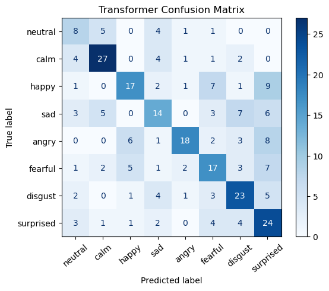

```python
evaluate_predictions(transformer, "Transformer", X_test=X_val, y_test=y_val)
```

### **SOTA**

Here we finetune the second iteration and base version of Facebook’s Wav2Vec model, described in their [paper](https://arxiv.org/abs/2006.11477) “wav2vec 2.0: A Framework for Self-Supervised Learning of Speech Representations.” This model has 95 million parameters and was trained on thousands of hours of raw speech audio data sampled at 16kHz. Because our own data is sampled at 48kHz, we downsampled each input to 16kHz. In order to implement the model, we used a Trainer object from the Transformers module, which is specialized for fine tuning pretrained models. We also employed the Transformer module’s AutoFeatureExtractor class, which normalizes and processes the audio data in a manner required by the model. Our code was heavily inspired by this HuggingFace [tutorial](https://huggingface.co/docs/transformers/en/tasks/audio_classification) on fine tuning an audio model. Due to long training time and limited GPU access on colab (ran into various pytorch dependency errors on Jupyter Hub), we were only able to train for 10 epochs, which took approximately 32 minutes.

#### **Data Preparation**

```python
audio_dataset = Dataset.from_dict({"audio": wav_paths}).cast_column("audio", AudioCast())
audio_dataset = audio_dataset.add_column('label', df['Emotion_Number']-1)
```

```python
audio_dataset = audio_dataset.train_test_split(test_size=0.2)
```

```python
feature_extractor = AutoFeatureExtractor.from_pretrained("facebook/wav2vec2-base")
```

```python
audio = audio_dataset.cast_column("audio", AudioCast(sampling_rate=16_000))
```

```python
def preprocess_function(examples):
    audio_arrays = [x["array"] for x in examples["audio"]]
    inputs = feature_extractor(
        audio_arrays, sampling_rate=feature_extractor.sampling_rate, padding='longest')
    return inputs
```

```python
encoded_audio = audio.map(preprocess_function, remove_columns="audio", batched=True)
```

#### **Load Model**

```python
accuracy = evaluate.load("accuracy")
```

```python
def compute_metrics(eval_pred):
    predictions = np.argmax(eval_pred.predictions, axis=1)
    return accuracy.compute(predictions=predictions, references=eval_pred.label_ids)
```

```python
num_labels = len(id2label)

##Load Wav2Vec Model
model = AutoModelForAudioClassification.from_pretrained(
    "facebook/wav2vec2-base", num_labels=num_labels, label2id=label2id, id2label=id2label
)
```

```
Some weights of Wav2Vec2ForSequenceClassification were not initialized from the model checkpoint at facebook/wav2vec2-base and are newly initialized: ['classifier.bias', 'classifier.weight', 'projector.bias', 'projector.weight', 'wav2vec2.encoder.pos_conv_embed.conv.parametrizations.weight.original0…
You should probably TRAIN this model on a down-stream task to be able to use it for predictions and inference.
```

```python
summary(model)
```

```
================================================================================
Layer (type:depth-idx)                                  Param #
================================================================================
Wav2Vec2ForSequenceClassification                       --
├─Wav2Vec2Model: 1-1                                    768
│    └─Wav2Vec2FeatureEncoder: 2-1                      --
│    │    └─ModuleList: 3-1                             4,200,448
│    └─Wav2Vec2FeatureProjection: 2-2                   --
│    │    └─LayerNorm: 3-2                              1,024
│    │    └─Linear: 3-3                                 393,984
│    │    └─Dropout: 3-4                                --
│    └─Wav2Vec2Encoder: 2-3                             --
│    │    └─Wav2Vec2PositionalConvEmbedding: 3-5        4,719,488
│    │    └─LayerNorm: 3-6                              1,536
│    │    └─Dropout: 3-7                                --
│    │    └─ModuleList: 3-8                             85,054,464
├─Linear: 1-2                                           196,864
├─Linear: 1-3                                           2,056
================================================================================
Total params: 94,570,632
Trainable params: 94,570,632
Non-trainable params: 0
================================================================================
```

[figure not shown]

```python
#Load model that was trained on Google Colab
# model = AutoModelForAudioClassification.from_pretrained('models/wav2vec10epochs')
```

#### **Configure & Train Model**

```python
# training_args = TrainingArguments(
#     output_dir="wav2vec2_audio",
#     evaluation_strategy="epoch",
#     save_strategy="epoch",
#     learning_rate=3e-5,
#     per_device_train_batch_size=32,
#     gradient_accumulation_steps=4,
#     per_device_eval_batch_size=32,
#     num_train_epochs=10,
#     warmup_ratio=0.1,
#     logging_steps=10,
#     load_best_model_at_end=True,
#     metric_for_best_model="accuracy"
# )

# trainer = Trainer(
#     model=model,
#     args=training_args,
#     train_dataset=encoded_audio["train"],
#     eval_dataset=encoded_audio["test"],
#     tokenizer=feature_extractor,
#     compute_metrics=compute_metrics,
# )

# trainer.train()
```

```python
#load saved results from training on colab
metrics=pd.read_csv('TrainingResults.csv')

epochs=metrics['Epoch'].to_list()
train_loss=metrics['Training Loss'].to_list()
val_loss=metrics['Validation Loss'].to_list()
val_accuracy=metrics['Validation Accuracy'].to_list()
```

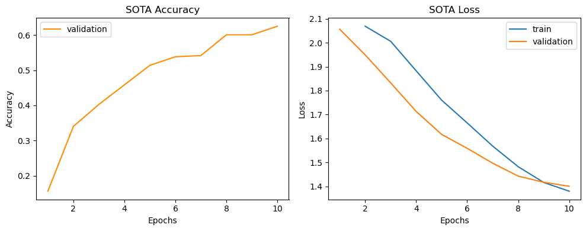

```python
plt.figure(figsize=(10, 4))

# Plot validation accuracy
plt.subplot(1, 2, 1)
plt.plot(epochs, val_accuracy, c='darkorange', label='validation')
plt.title('SOTA Accuracy')
plt.xlabel('Epochs')
plt.ylabel('Accuracy')
plt.legend()

# Plot training and validation loss
plt.subplot(1, 2, 2)
plt.plot(epochs[1:], train_loss[1:], label='train')
plt.plot(epochs, val_loss, label='validation')
plt.title('SOTA Loss')
plt.xlabel('Epochs')
plt.ylabel('Loss')
plt.legend()

plt.tight_layout()  # Adjust layout to prevent overlapping
plt.show()
```

Both training and validation loss decrease steadily with more epochs. Validation accuracy increases until 62.5% by epoch 10. Although improvement in validation accuracy and decreases in loss appear to be slowly plateauing, these results indicate that training for more epochs would likely yield improved performance. With addition of data augmentation techniques like guassian noise, these results could potentially be improved further. Unfortunately lack of compute resources/time limited our ability to test out various hyperparameters.

#### **Evaluation & Analysis**

```python
### Get model predictions on validation set

# output = trainer.predict(encoded_audio['test'])

# predictions = output.predictions
# label_ids = output.label_ids
# metrics = output.metrics

# preds=[np.argmax(x) for x in predictions]
```

```python
#Load saved predictions
outputs_df = pd.read_csv('predictions.csv')
```

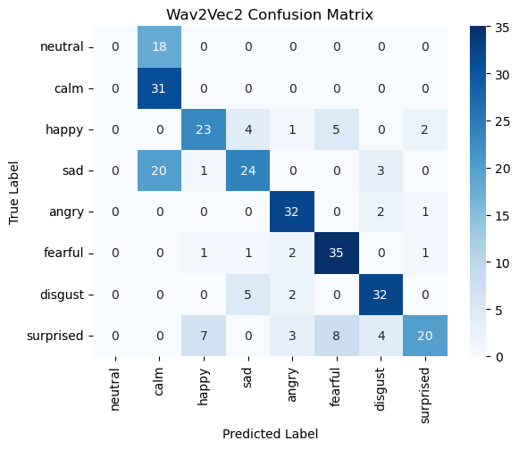

```python
sns.heatmap(confusion_matrix(outputs_df['labels'], outputs_df['preds']), annot=True, xticklabels = [id2label[i] for i in range(8)], yticklabels = [id2label[i] for i in range(8)], cmap='Blues');
plt.xlabel('Predicted Label')
plt.ylabel('True Label')
plt.title('Wav2Vec2 Confusion Matrix')
plt.show()
```

## **Discussion**

One area for future improvement for both the LSTM and Transformer models is trying to reduce the overfitting problem that typically happens in the early epochs, before the model has reached its best validation accuracy. We began to brief experiment with solutions to this with the LSTM model, but much more could be done with both models. Our intuition was to make the model learn more slowly, but still reach the same so that the validation accuracies could keep up. One idea that we began to test was to go back to the 4 layers LSTM approach but make all the layers much smaller (512-128 units). Because each layer is now learning a lot less, this model took a lot longer to train (250 epochs) and reached slight lower validation accuracies around 52%, but had a much better validation loss of 1.45. Additionally, when we plotted the graphs, the overfitting not only happened proportionally later, but also the validation accuracies where much closer to the training accuracies through out the training epochs. Using a similar approach we could test a 3 layer LSTM model and hyper-parameter tune the layers to see if this improves upon the overfitting problem. The later the model begins to overfit, the higher we think the validation accuracy can get as it will flatten our at a later time.

Another future improvement would be to perform a more rigorous and structured analysis to see what emotions are being learned at specific steps for each model. We briefly did this with the LSTM model by plotting the confusion matrix at intermediate times, while the model was training. However, if we were to run this analysis multiple times and keeping tract of the exact statistics, instead of visually performing an eye test, it would potentially be super useful; we could use this data to help us train our model to be able to differentiate between emotions that are close together or emotions that it tends to predict incorrectly.

While experimenting with the transformer model, we found a significant 5% improvement in accuracy by increasing the number of pitch frequencies returned by the Mel spectrogram at each time step. It is possible that more experimentation in this area could yield better results. One thing we were unable to do due to computation issues was invert the Mel spectrogram back to an audio file to find how much information was lost when converting to Mel spectrogram. It would be helpful to know how the audio file sounds after being transformed to Mel and back again. Another concept we did not try is overlapping windows. Our implementation with librosa separated the audio clip into discrete time windows, but others have had these windows overlap to create a more fluid transition between pitches across time. This fluidity might be important for emotion classification, or might enable us to increase complexity in a more meaningful way.

Another obvious way to improve the performance of our model(s) is to add more training data. This can include more voice actors saying the same phrases or labelled audio samples from other forms of media, for which the internet provides a seemingly infinite supply. This will allow the model to extract better representations from the audio data. A large part of the SOTA Wav2Vec2’s superior performance stems from the fact that it was pre-trained on a massive audio database, whereas our own models only saw the RAVDESS data. Moving beyond the same 24 voice actors and the same 2 phrases will result in purer and more complex features being learned. Deeper model architectures will also be required in order to capture patterns and temporal dependencies with strong predictive power. At the end of the day, no matter how complex a deep learning model is, it must be provided with enough high-quality data in order to work. For example, if you inputted a new phrase from a new voice into our custom models, they likely would return accuracies much worse than the validation data would suggest. If, however, we significantly added to our dataset, then the trained models should have learned features that allow it to generalize much better to unseen data.

With more time, we'd also love to continue exploring the use of CNNs for this task. A convolutional neural network seems like a fruitful option given the sheer amount of data we need to take as input. Even once it has been processed via. the Mel Spectrogram, there are still $128 * 495 = 63360$ values for each audio sample. We'd like to detect the key features of the data using convolutional filters, much like we do for images. A working theory is that each emotion may be associated with certain patterns of frequencies or amplitudes, and the convolutional layers may be able to detect these patterns. Anger, for example, may be associated with higher amplitude bursts for louder voices or higher frequency bursts for sped-up talking. Additionally, the shift-invariance of CNN's will also be very beneficial. It should, in theory, not matter whether the patterns associated with anger appear at the beginning or end of the audio sample, so we don't want to take their position into account. For some reason, however, the CNNs just were not working, despite our best efforts. The loss was astronomical, and we could never exceed an accuracy of around 18% (essentially a pure guess between the options). We believe that this could be caused by non-neighborial relations in the Mel Spectrogram output, but we would need more time to explore this.

Overall, we were content with our progress on this challenging task, and very much enjoyed exploring the world of audio networks.